# Question 4 - Logistic regression analysis

### Conceptual model

The underlying conceptual model here is to study if the age,gender and/or estimated salary of a person can explain whether they purchased a product advertised online.

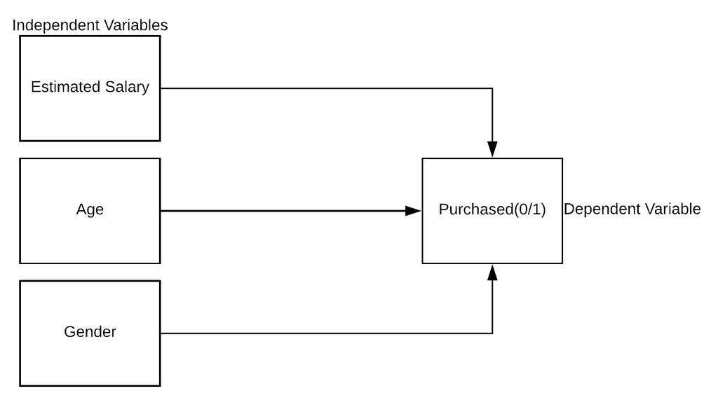

### Logistic regression

```r
mydata <- read.csv("D:\\Learning Material\\SDs\\Social_Network_Ads_Cleaned.csv")
mydata$Purchased<-factor(mydata$Purchased, levels = c(0:1), labels = c("No","Yes"))
cat("The levels of gender variable: \n")
```

```
The levels of gender variable:
```

```r
levels(mydata$Gender)
```

```
[1] "Female" "Male"
```

```r
cat("The levels of purchased variable: \n")
```

```
The levels of purchased variable:
```

```r
levels(mydata$Purchased)
```

```
[1] "No"  "Yes"
```

```r
cat("The summary of the data: \n")
```

```
The summary of the data:
```

```r
summary(mydata)
```

```
    Gender         Age        EstimatedSalary  Purchased
 Female:181   Min.   :18.00   Min.   : 15000   No :231
 Male  :178   1st Qu.:29.50   1st Qu.: 43000   Yes:128
              Median :37.00   Median : 69000
              Mean   :37.64   Mean   : 69462
              3rd Qu.:46.00   3rd Qu.: 88000
              Max.   :60.00   Max.   :150000
```

As taught in class, we made sure to factorize the categorical variable namely gender and purchased as can be seen above. We were also interested in looking at the summary of the data to understand it’s contents.

### Visualizing the data

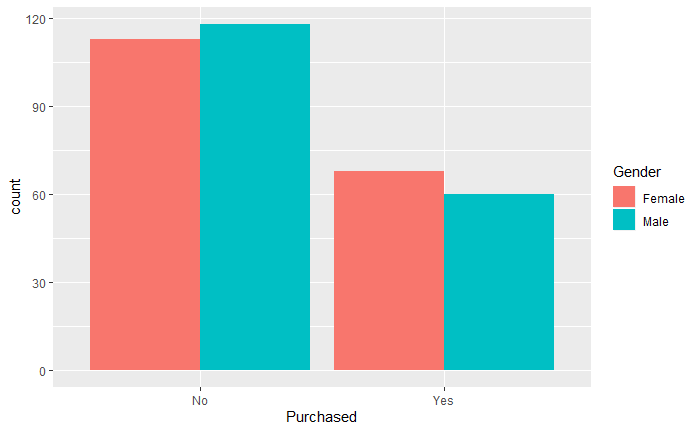

```r
ggplot(mydata, aes(Purchased, ..count..)) + geom_bar(aes(fill = Gender), position = "dodge")
```

Here we see that in general women have made more online purchases than men. And that in general there are less successful purchases online.

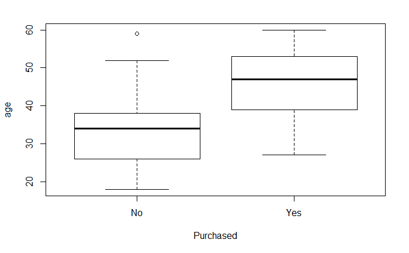

```r
plot(mydata$Purchased, mydata$Age, xlab = "Purchased", ylab = "age")
```

Here we clearly see that older people make more purchases.

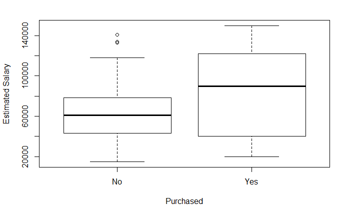

```r
plot(mydata$Purchased, mydata$EstimatedSalary, xlab = "Purchased", ylab = "Estimated Salary")
```

Here we see that usually people with more money make more purchases which seems to make sense.

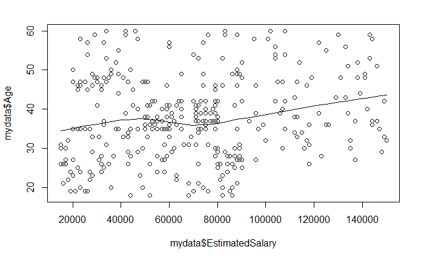

```r
scatter.smooth(mydata$EstimatedSalary,mydata$Age)
```

Here as expected we see that there is a slight positive correlation between age and estimated salary. People with more money are usually also older.

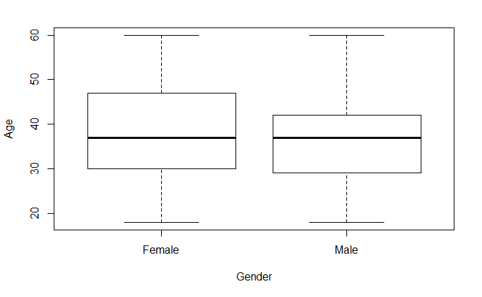

```r
plot(mydata$Gender, mydata$Age, xlab = "Gender", ylab = "Age")
```

Here we see that variance of age for both genders is similar in our data. This is good because we can truly consider gender to be independent of age.